# Discrete Random Variables

Stat 2510: Statistical Methods

2026

## Random Variables

In this section students will:

1. Learn and understand random variable notation
2. Learn what a probability distribution is
3. List the features of a probability distribution function

## Terminology

A random variable describes the outcomes of a statistical experiment in words. The values of a random variable can vary with each repetition of an experiment.

Upper case letters such as $X$ or $Y$ denote a random variable. Lower case letters like $x$ or $y$ denote the value of a random variable.

If $X$ is a random variable, then $X$ is written in words, and $x$ is given as a number.

For example, let $X$ = the number of heads you get when you toss three fair coins. The sample space for the toss of three fair coins is TTT, TTH, THT, HTT, HHT, HTH, THH, HHH. Then, $x=0,1,2,3$. $X$ is in words and $x$ is a number.

Notice that for this example, the $x$ values are countable outcomes. Because you can count the possible values that $X$ can take on and the outcomes are random (the $x$ values 0, 1, 2, 3), $X$ is a discrete random variable.

Calculations of probabilities for flipping a coin three times (or flipping 3 coins):

$X$ is the number of heads  
$x$ are the outcomes: $x=0,1,2,3$  
All probabilities are valid: $0\le X \le 1$  
All probabilities sum to $1$: $\sum p(x)=1$

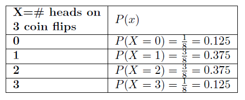

Probability distribution of flipping 3 coins

## Discrete Probability Distribution

A **probability distribution** is a mathematical description of the probabilities of events, subsets of the sample space. The sample space, often represented in notation by $S$ is the set of all possible outcomes of a random phenomenon being observed; it may be any set: a set of real numbers, a set of descriptive labels, a set of vectors, a set of arbitrary non-numerical values, etc.

## Probability Rules Recap

1. Valid probability rule: $0\leq P(A)\leq1$
2. Total probability rule: $\sum P(A_i)=1=S$
3. Complement rule: $P(A')=1-P(A)$
4. Addition rule: $P(A \cup B)=P(A)+P(B)-P(A\cap B)$
5. Multiplication rule: $P(A\cap B)=P(A)P(B)$ (independent events only)

## Discrete Example

A child psychologist is interested in the number of times a newborn baby’s crying wakes its parental unit after midnight. For a random sample of 50 parents, the following information was obtained. Let $X$ = the number of times per week a newborn baby’s crying wakes its parent after midnight. For this example, $x = 0, 1, 2, 3, 4, 5$. $P(X=x)=P(x)$ = probability that $X$ takes on a value $x$.

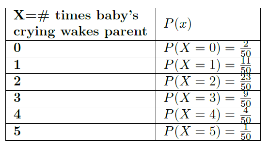

Probability distribution of crying babies

$X$ is the number of times baby wakes parent  
$x$ takes on the values 0, 1, 2, 3, 4, 5.

This is a discrete PDF because:  
Each $P(X=x)$ is between zero and one, inclusive  
The sum of the probabilities is one

## Expected Value (mean) and Standard Deviation

In this section students will:

1. Calculate the expected value of a discrete probability distribution
2. Calculate the variance of a discrete probability distribution
3. Calculate the standard deviation of a discrete probability distribution

## Expected Value

Since not all values of a random variable have the same probability, to calculate the mean, we have to approach it in a slightly different way. The mean is called an **Expected Value ($E(X)$)**. It is a weighted mean (weighted average); meaning some values have a greater chance of happening than others.

$$E(X)=\sum
xp(x_i)=x_1p(x_1)+x_2p(x_2)+\cdots+x_np(x_n)$$

The expected value is often referred to as the “long-term” average or mean.

This means that over the long term of doing an experiment over and over, you would expect this average.

The Law of Large Numbers states that, as the number of trials in a probability experiment increases, the difference between the theoretical probability of an event and the relative frequency approaches zero (the theoretical probability and the relative frequency get closer and closer together).

When evaluating the long-term results of statistical experiments, we often want to know the “average” outcome.

This “long-term average” is known as the **mean** or **expected value** of the experiment and is denoted by the Greek letter $\mu$.

In other words, after conducting many trials of an experiment, you would expect this average value.

## Calculate $EX$

A men’s soccer team plays soccer zero, one, or two days a week. The probability that they play zero days is 0.2, the probability that they play one day is 0.5, and the probability that they play two days is 0.3. How many days per week, on average, would we expected the men’s soccer team to play soccer?

The expected value is 1.1.

The men’s soccer team would, on the average, expect to play soccer 1.1 days per week. The number 1.1 is the long-term average or expected value if the men’s soccer team plays soccer week after week after week.

## $EX$ example 2

Suppose you play a game with a biased coin. You play each game by tossing the coin once. $P(heads)=\frac23$ and $P(tails)=\frac13$. If you toss a head, you pay $6. If you toss a tail, you win $10. If you play this game many times, will you come out ahead?

1. Define a random variable $X$
2. What is the expected value? Do you come out ahead?

Define random variable $X$ (and $x$)  
$X=$ number of heads in one trial (one coin flip)  
$x={-\$6,\$10}$

$E(X)=\sum xp(x_i)=-6(2/3)+10(1/3)=-2/3$; not coming out ahead (behind by almost $0.70)

## Variance and Standard deviation

Variance:
$$VX=\sum(x-EX)^2p(x)$$

Standard deviation:
$$SDX=\sqrt{VX}$$

Example from previous slide:
$$VX=(-6--2/3)^2(2/3)+(10--2/3)^2(1/3)=56.8888889$$
$$SDX=\sqrt{VX}=\sqrt{56.8888889}=7.5424723$$

## The Binomial Distribution

In this section students will:

1. Graph discrete probability distributions
2. Compute binomial probabilities using the Binomial Probability formula, a binomial distribution table and/or graphing calculator
3. Use the binomial probability distribution to solve real-world applications
4. Compute mean and standard deviation for a binomial distribution

## Characteristics of Binomial Distribution

There are four characteristics of a binomial experiment.

1. $n$, the number of trials, are fixed
2. Only two outcomes are possible: success with probability $p$, and failure with probability $q=1-p$
3. The probability of success, $p$, is constant from trial to trial
4. The $n$ trials are independent

## Notation for Binomial Distribution

The outcomes of a binomial experiment fit a binomial probability distribution.

The random variable $X=$ the number of successes obtained in the n independent trials.

The parameters are $n$ and $p$: $n=$ number of trials, $p=$ probability of a success on each trial.

$$\text{Shorthand notation: }X\sim
bin(n,p) \text{ or }X\sim B(n,p)$$
Read this as “$X$ is a random variable with a binomial distribution with parameters n and p.”

Binomial probabilities are found by using the binomial distribution function. Stating the probability question mathematically is the start.

Formula:
$$P(X=x)=\binom{n}{x}p^xq^{n-x}~~~~~x=0,1,\cdots,n$$
$$\binom{n}{x}=\frac{n!}{x!(n-x)!}$$
is a combination and reads as “n choose x.” It is the number of ways that $x$ things can be chosen from $n$ trials (number of ways to get a sum of 7 when rolling two 6-sided dice, as an example).

**Note**: *the exponents of $p$ and $q$ MUST sum to $n$ ($x+(n-x)=n$) AND $p+q=1$*

Expected value, variance, standard deviation
$$EX=np~~~VX=npq~~~SDX=\sqrt{npq}$$

## Factorial Review

$\binom{n}{x}$ is a combination and reads as “n choose x.” It is the number of ways that $x$ things can be chosen from $n$ trials (as an example, the number of ways to get a sum of 7 when rolling two 6-sided dice).

$\binom{n}{x}=\frac{n!}{x!(n-x)!}$ with $n!=n(n-1)(n-2)(n-3)\ldots 1$. This function is found on most calculators and websites (one is linked in this Module in Canvas)

Some hints with combinations:

$$\binom{n}{n}=1,~\binom{n}{1}=n,~
\binom{n}{n-1}=n,~ \binom{n}{0}=1$$

## Binomial Example

A fair coin is flipped 15 times. Each flip is independent. What is the probability of getting exactly 10 heads? What is the probability of getting more than 12 heads?

Let $X=$ the number of heads in 15 flips of the fair coin. $X$ takes on the values $x=0, 1, 2, 3, \cdots, 15$. Since the coin is fair, $p=0.5$ and $q=1-p=0.5$. The number of trials is $n=15$. State the probability question mathematically and calculate it

$$P(X=10)=\binom{n}{x}p^xq^{n-x}=\binom{15}{10}(0.5)^{10}(0.5)^{15-10}=
(3003)(0.5)^{10}(0.5)^5=0.0916$$
$$P(X>12)=P(X\ge13)=P(X=13)+P(X=14)+P(X=15)$$

$$\binom{15}{13}(0.5)^{13}(0.5)^{15-13}=
(105)(0.5)^{13}(0.5)^2=0.0032$$
$$\binom{15}{14}(0.5)^{14}(0.5)^{15-14}=
(15)(0.5)^{14}(0.5)=5\times 10^{-4}$$
$$\binom{15}{15}(0.5)^{15}(0.5)^{15-15}=
(1)(0.5)^{15}(0.5)^0=0$$
$$P(X>12)=0.0032+5\times
10^{-4}+0=0.0037$$

[Note: you could calculate the probabilities the way we initially did with flipping a coin two times and for flipping a coin three times but using the binomial distribution for flipping a coin $15$ times is easier and less time-consuming. Either way is correct but using the binomial for flipping more than 3 coins is easier]

## Binomial Graph

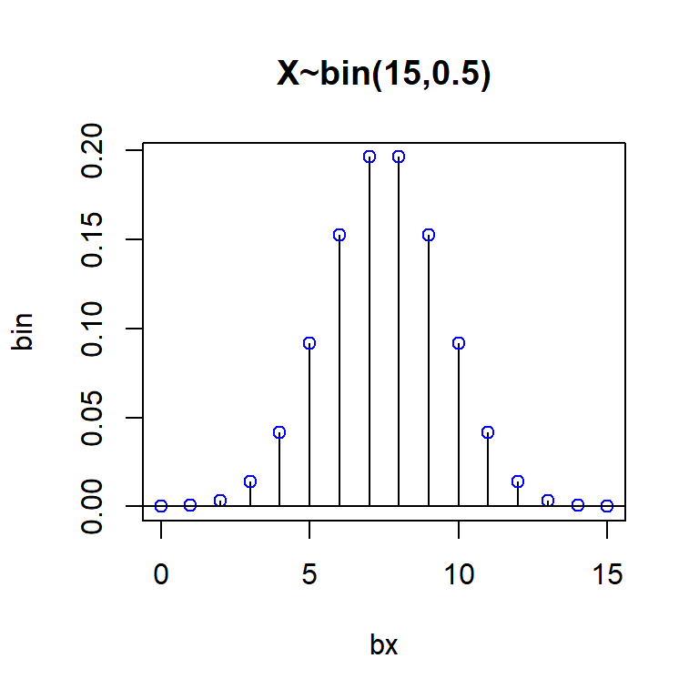

## Binomial Example 2

About 32% of students participate in a community volunteer program outside of school. If 15 students are selected at random, find the probability that at least 2 of them participate in a community volunteer program outside of school. How many students, on average, participate in a community volunteer program outside of school? Also calculate the variance and standard deviation.

$$n=15,~p=0.32~q=1-p=1-0.32=0.68$$
and thus
$$X\sim bin(15, 0.32)$$

$$P(X\ge
2)=P(2)+P(3)+\cdots+P(15)$$
OR!
$$P(X\ge 2)=1-P(X<2)=1-P(X\le
1)=1-[P(0)+P(1)]$$
$$P(X=0)=\binom{15}{0}(0.32)^{0}(0.68)^{15-0}=(1)(0.32)^{0}(0.68)^{15}=0.0031$$
$$P(X=1)=\binom{15}{1}(0.32)^{1}(0.68)^{15-1}=(15)(0.32)^{1}(0.68)^{14}=0.0217$$
$$P(X\ge
2)=1-[P(0)+P(1)]=1-(0.0031+0.0217)=1-0.0248=0.9752$$
$$EX=np=15(0.32)=4.8$$

$$VX=npq=15(0.32)(0.68)=3.26$$

$$SDX=\sqrt{VX}=\sqrt{3.26}=1.81$$

## Binomial Graph 2

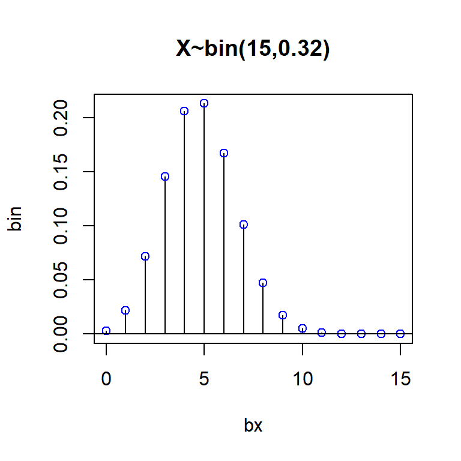

## Poisson distribution

There are three assumptions for an experiment to have a Poisson distribution, and is used in modelling rare events

1. The occurrence of one event does not affect the probability that a second event will occur. That is, events occur independently
2. The rate at which events occur is constant. The rate cannot be higher in some intervals and lower in other intervals
3. Two events cannot occur at exactly the same instant; instead, at each very small sub-interval exactly one event either occurs or does not occur

**The probability is the probability of the number of events happening **within a specified period**; the number of times an event occurs in an interval of *time or space*.**

One of the things this distribution was used for was to model the number of horse kicks Prussian soldiers received (seriously, go look it up!)

## Poisson logistics

Poisson is pronounced as “pwa-so(n)”. If you have seen The Little Mermaid, recall the song that the chef sings when Sebastian is running from him in the kitchen [Little Mermaid: Les Poissons](https://www.youtube.com/watch?v=UoJxBEQRLd0&ab_channel=DisneyMusicVEVO)

$$\text{Shorthand notation: }X\sim
pois(\mu)~or~X\sim P(\mu)$$
$\mu$ is the average or a rate (use $\mu=np$, $EX$ from binomial)
You are allowed to use your calculator to do as much of the calculation as you want. There are instructions in the book on how to use the command if you have a TI graphing calculator on p. 267.

## Poisson formulas

$$P(X=x)=\frac{e^{-\mu}
\mu^x}{x!}~~~x=0,1,\cdots,\infty$$

$$EX=\mu$$
$$VX=\mu$$
$$SDX=\sqrt{\mu}$$

## Poisson example

Consider an experiment that consists of counting the number of $\alpha$-particles given off in a 1-second time interval by 1 gram of radioactive material. If the average number of $\alpha$-particles given off is 3.2, what is the probability of exactly 2 $\alpha$-particles given off in the next 1-second interval? What is the probability that no $\alpha$-particles are given off in the next 1-second interval? More than 2 $\alpha$-particles?

$$X\sim pois(3.2)~or~X\sim
P(3.2)$$

$$P(X=x)=\frac{e^{-\mu}
\mu^x}{x!}$$

## Poisson example continued

$$P(X=2)=\frac{e^{-3.2}3.2^2}{2!}=0.2087025$$
$$P(X=0)=\frac{e^{-3.2}3.2^0}{0!}=0.0407622$$

$$P(X>2)=1-P(X\le2)=1-[P(2)+P(1)+P(0)]$$
$$=1-\left(\frac{e^{-3.2}3.2^2}{2!}+\frac{e^{-3.2}3.2^1}{1!}+\frac{e^{-3.2}3.2^0}{0!}\right)$$
$$=1-0.3799037=0.6200963$$

## Poisson graph

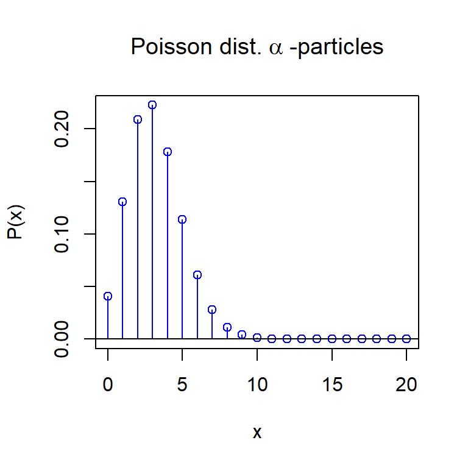

## Poisson $EX$, $VX$, $SDX$

$$EX=\mu=3.2$$
$$VX=\mu=3.2$$
$$SDX=\sqrt{VX}=\sqrt{\mu}=\sqrt{3.2}=1.7888544$$